# Instituto Internacional de Aguascalientes

## Maestría en Inteligencia Artificial para la Transformación Digital

### Programa: Aprendizaje Inteligente

## Práctica: Análisis, implementación y prueba de máquinas de aprendizaje supervisado mediante K-Folds aplicado al dataset de diabetes

**Alumno:** Antonio Nicolás Toro González

**Tutor:** Dr. Francisco Javier Luna Rosas

**Ciudad de México, julio de 2026**

## Repositorios y URL

**Repositorio GitHub:**  
https://github.com/antoniot73/ml_kfolds_diabetes_supervisado

**URL Binder:**  
https://mybinder.org/v2/gh/antoniot73/ml_kfolds_diabetes_supervisado/main?filepath=notebooks/practica_kfolds_diabetes_supervisado.ipynb

**GitHub Page:**  
https://antoniot73.github.io/ml_kfolds_diabetes_supervisado/notebooks/practica_kfolds_diabetes_supervisado.html

**Dataset utilizado:**  
https://www.kaggle.com/datasets/uciml/pima-indians-diabetes-database

## 1. Marco teórico y analítico

### 1.1 Aprendizaje supervisado y clasificación binaria

El aprendizaje supervisado permite construir modelos predictivos a partir de datos previamente etiquetados. En un problema de clasificación, se dispone de una base de datos:

$$ D = \{t_1, t_2, ..., t_n\} $$

formada por registros o individuos, y de un conjunto de clases:

$$ C = \{C_1, C_2, ..., C_m\} $$

El objetivo consiste en encontrar una función:

$$ f:D \rightarrow C $$

capaz de asignar cada registro $t_i$ a una clase $C_j$. En esta práctica, la función de clasificación se aproxima mediante tres máquinas de aprendizaje supervisado: **Random Forest**, **Máquina de Soporte Vectorial** y **Red Neuronal Multicapa**. La comparación se realiza con **K-Fold Cross-Validation (K-Folds)** para estimar el comportamiento predictivo de los modelos mediante particiones reproducibles y estratificadas.

### 1.2 Dataset de diabetes

Se utiliza el archivo `diabetes.csv`, compuesto por 768 registros y nueve columnas. Cada registro representa una observación clínica descrita mediante variables numéricas relacionadas con embarazos, glucosa, presión arterial, grosor de piel, insulina, índice de masa corporal, función de pedigrí diabético, edad y una variable objetivo binaria.

La variable objetivo es `Outcome`, donde:

- `0`: paciente sin diagnóstico positivo de diabetes.
- `1`: paciente con diagnóstico positivo de diabetes.

El uso de este dataset permite plantear un problema supervisado de clasificación binaria, en el que los modelos deben aprender patrones clínicos asociados con la presencia o ausencia de diabetes. Esta práctica tiene finalidad académica y no debe interpretarse como sistema clínico de diagnóstico.

### 1.3 K-Fold Cross-Validation (K-Folds)

K-Fold Cross-Validation es una técnica de validación cruzada que divide el conjunto de datos en $k$ subconjuntos o *folds* de tamaño similar. En cada iteración, uno de los folds se utiliza como conjunto de prueba y los $k-1$ folds restantes se emplean para entrenar el modelo. El proceso se repite $k$ veces, de manera que cada fold funciona exactamente una vez como conjunto de prueba.

El error promedio de K-Folds puede representarse como:

$$ CV_k = \frac{1}{k}\sum_{i=1}^{k}E_i $$

donde $E_i$ es el error obtenido en el fold $i$.

En esta práctica se utiliza **K-Folds estratificado con $k=10$**, una variante adecuada para clasificación binaria porque conserva aproximadamente la proporción de clases en cada partición. Esta decisión permite comparar Random Forest, SVM Lineal y Red Neuronal MLP bajo una estrategia reproducible, equilibrada y computacionalmente eficiente y robusta para clasificación supervisada.

### 1.4 Random Forest

Random Forest es un método de ensamble que combina múltiples árboles de decisión. Cada árbol se entrena sobre una muestra bootstrap del conjunto de datos y, en cada división, considera un subconjunto aleatorio de variables. La predicción final se obtiene por votación mayoritaria en clasificación.

En esta práctica, Random Forest es pertinente porque puede capturar relaciones no lineales entre las variables clínicas y la clase `Outcome`. Además, reduce la varianza de un árbol individual mediante agregación, lo que lo convierte en un modelo robusto para clasificación tabular.

### 1.5 Máquina de Soporte Vectorial (SVM)

La Máquina de Soporte Vectorial es un clasificador supervisado que busca construir un hiperplano de separación entre clases maximizando el margen geométrico. Los puntos más cercanos al hiperplano se denominan vectores de soporte, porque determinan la frontera de decisión.

En esta práctica se utiliza una SVM Lineal dentro de un pipeline con estandarización. La estandarización es necesaria porque SVM depende de escalas numéricas y distancias geométricas en el espacio de características.

### 1.6 Red Neuronal Multicapa (MLP)

Una red neuronal multicapa es un modelo supervisado no lineal compuesto por capas de neuronas artificiales. Cada neurona aplica una combinación ponderada de entradas y una función de activación. Durante el entrenamiento, el modelo ajusta sus pesos para reducir el error de clasificación.

En esta práctica se implementa una arquitectura compacta mediante `MLPClassifier`, adecuada para datos tabulares de tamaño moderado. Al igual que SVM, requiere estandarización de variables para mejorar la estabilidad del entrenamiento.

### 1.7 Métricas solicitadas para la prueba de modelos

La evaluación comparativa se realiza a partir de la matriz de confusión:

| Elemento | Significado |
| --- | --- |
| TP | Verdaderos positivos: pacientes positivos correctamente clasificados. |
| TN | Verdaderos negativos: pacientes negativos correctamente clasificados. |
| FP | Falsos positivos: pacientes negativos clasificados como positivos. |
| FN | Falsos negativos: pacientes positivos clasificados como negativos. |

A partir de estos elementos se calculan:

$$ Precisión\ Global = \frac{TP + TN}{TP + TN + FP + FN} $$

$$ Error\ Global = \frac{FP + FN}{TP + TN + FP + FN} $$

$$ PP = \frac{TP}{TP + FN} $$

$$ PN = \frac{TN}{TN + FP} $$

$$ AP = \frac{TP}{TP + FP} $$

$$ NP = \frac{TN}{TN + FN} $$

donde **PP** representa la precisión positiva o sensibilidad, **PN** representa la precisión negativa o especificidad, **AP** representa la asertividad positiva y **NP** representa la asertividad negativa.

## 2. Motivación de la práctica

La práctica busca comprender el funcionamiento de máquinas de aprendizaje supervisado mediante una implementación reproducible y comparable. En lugar de utilizar una sola partición entrenamiento-prueba, se aplica **K-Fold Cross-Validation** para evaluar el desempeño de los modelos en varias particiones del dataset.

El dataset de diabetes permite conectar el aprendizaje supervisado con un problema aplicado de salud, reforzando la interpretación de aciertos y errores. En este contexto, los falsos negativos son especialmente relevantes porque representan pacientes positivos clasificados como negativos.

## 3. Planteamiento del problema

Cada registro del dataset representa una observación clínica descrita por variables predictoras numéricas. El problema consiste en clasificar cada registro en una de dos clases:

$$ C = \{0, 1\} $$

donde:

- `0`: resultado negativo.
- `1`: resultado positivo.

La función de clasificación será aproximada mediante:

$$ f_{RF}:D \rightarrow C $$

$$ f_{SVM}:D \rightarrow C $$

$$ f_{MLP}:D \rightarrow C $$

El objetivo experimental es comparar los modelos usando **K-Folds** y las métricas solicitadas: precisión global, error global, precisión positiva, precisión negativa, falsos positivos, falsos negativos, asertividad positiva y asertividad negativa.

## 4. Implementación en Python

La implementación se realiza en Python utilizando una estructura modular dentro del notebook. Se conserva el estilo de la práctica de referencia: configuración de rutas, logging, carga de datos, validación, visualización con scroll, preparación de variables, entrenamiento con **K-Folds**, evaluación mediante matrices de confusión, tablas comparativas y generación de gráficas.

### Paquetes de Python utilizados

| Paquete | Uso en la práctica |
| --- | --- |
| `pathlib` | Gestión de rutas del proyecto. |
| `logging` | Registro de eventos del pipeline. |
| `numpy` | Operaciones numéricas. |
| `pandas` | Carga, validación y manipulación del dataset. |
| `matplotlib` | Generación de gráficas. |
| `IPython.display` | Visualización HTML del dataset con scroll. |
| `sklearn.model_selection` | Implementación de K-Folds mediante `StratifiedKFold` y `cross_val_predict`. |
| `sklearn.pipeline` | Integración de escalamiento y modelo sin fuga de datos. |
| `sklearn.preprocessing` | Estandarización de variables. |
| `sklearn.ensemble` | Implementación de Random Forest. |
| `sklearn.svm` | Implementación de SVM Lineal. |
| `sklearn.neural_network` | Implementación de Red Neuronal MLP. |
| `sklearn.metrics` | Matrices de confusión y métricas de clasificación. |

### Documentación técnica mediante docstrings

El notebook incluye funciones documentadas mediante docstrings. Cada docstring explica el propósito de la función, sus entradas, salidas, validaciones, excepciones y su papel dentro del pipeline. Esto permite que la práctica sea reproducible, verificable y mantenible.

```python
# Configuración general del proyecto, rutas, dependencias y logging.

from pathlib import Path
import base64
import logging
import sys
import warnings
from typing import Iterable

import numpy as np
import pandas as pd
import matplotlib
matplotlib.use("Agg")
import matplotlib.pyplot as plt

from IPython.display import HTML, Image, display

from sklearn.model_selection import StratifiedKFold, cross_val_predict
from sklearn.pipeline import Pipeline
from sklearn.preprocessing import StandardScaler
from sklearn.ensemble import RandomForestClassifier
from sklearn.svm import LinearSVC
from sklearn.neural_network import MLPClassifier
from sklearn.metrics import confusion_matrix, ConfusionMatrixDisplay

warnings.filterwarnings("ignore")


display(HTML("""
<style>
    .jp-Notebook,
    .notebook_app,
    body {
        overflow-x: hidden;
    }

    .output_subarea,
    .output_html,
    .rendered_html {
        max-width: 100% !important;
    }

    .rendered_html table {
        max-width: 100%;
    }

    @media (max-width: 768px) {
        .rendered_html {
            font-size: 14px;
        }

        .output_png img,
        .jp-RenderedImage img {
            max-width: 100% !important;
            height: auto !important;
        }
    }
</style>
"""))


CURRENT_DIR = Path.cwd()

if CURRENT_DIR.name == "notebooks":
    PROJECT_ROOT = CURRENT_DIR.parent
else:
    PROJECT_ROOT = CURRENT_DIR

DATA_DIR = PROJECT_ROOT / "data"
OUTPUT_DIR = PROJECT_ROOT / "outputs"
OUTPUT_GRAPHS = OUTPUT_DIR / "graficas"
OUTPUT_TABLES = OUTPUT_DIR / "tablas"

for directory in [DATA_DIR, OUTPUT_DIR, OUTPUT_GRAPHS, OUTPUT_TABLES]:
    directory.mkdir(parents=True, exist_ok=True)

logging.basicConfig(
    level=logging.INFO,
    format="%(asctime)s | %(levelname)s | %(message)s",
    handlers=[logging.StreamHandler(sys.stdout)],
    force=True,
)

LOGGER = logging.getLogger("kfolds_diabetes_pipeline")
N_SPLITS = 10
RANDOM_STATE = 42

def format_relative_path(path: Path) -> str:
    """Devuelve una ruta relativa legible respecto al directorio del proyecto.

    Args:
        path: Ruta absoluta o relativa que se desea mostrar en consola.

    Returns:
        Cadena con la ruta relativa cuando es posible; de lo contrario,
        devuelve la ruta original como texto.

    Raises:
        TypeError: Si el argumento no es una instancia de pathlib.Path.
    """
    if not isinstance(path, Path):
        raise TypeError("path debe ser una instancia de pathlib.Path.")

    try:
        return str(path.relative_to(PROJECT_ROOT))
    except ValueError:
        return str(path)
```

```python
# Funciones de carga, validación y visualización HTML del dataset.

REQUIRED_COLUMNS = [
    "Pregnancies",
    "Glucose",
    "BloodPressure",
    "SkinThickness",
    "Insulin",
    "BMI",
    "DiabetesPedigreeFunction",
    "Age",
    "Outcome",
]

FEATURE_COLUMNS = [
    "Pregnancies",
    "Glucose",
    "BloodPressure",
    "SkinThickness",
    "Insulin",
    "BMI",
    "DiabetesPedigreeFunction",
    "Age",
]


def load_diabetes_dataset(csv_path: Path) -> pd.DataFrame:
    """Carga el dataset de diabetes desde un archivo CSV.

    Esta función representa la fase de ingestión de datos del pipeline.
    Lee el archivo original, valida que exista y devuelve un DataFrame
    para las etapas posteriores de validación, exploración y modelado.

    Args:
        csv_path: Ruta del archivo CSV `diabetes.csv`.

    Returns:
        DataFrame con los registros clínicos cargados.

    Raises:
        FileNotFoundError: Si el archivo CSV no existe.
        ValueError: Si el archivo existe pero no contiene registros.
        RuntimeError: Si ocurre un error inesperado durante la lectura.
    """
    if not isinstance(csv_path, Path):
        raise TypeError("csv_path debe ser una instancia de pathlib.Path.")

    if not csv_path.exists():
        raise FileNotFoundError(f"No se encontró el archivo: {csv_path}")

    try:
        df_loaded = pd.read_csv(csv_path)
    except Exception as exc:
        LOGGER.exception("Error al cargar el dataset.")
        raise RuntimeError("No fue posible cargar el dataset de diabetes.") from exc

    if df_loaded.empty:
        raise ValueError("El dataset está vacío.")

    LOGGER.info("Dataset cargado correctamente desde %s", format_relative_path(csv_path))
    return df_loaded


def validate_diabetes_dataset(df_input: pd.DataFrame, required_columns: Iterable[str]) -> None:
    """Valida la estructura mínima del dataset de diabetes.

    La validación revisa columnas obligatorias, valores faltantes,
    variable objetivo binaria y tipos numéricos. Esta etapa evita entrenar
    modelos sobre datos inconsistentes.

    Args:
        df_input: DataFrame cargado desde el archivo CSV.
        required_columns: Colección de nombres de columnas obligatorias.

    Returns:
        None. La función finaliza sin retorno si la validación es correcta.

    Raises:
        TypeError: Si df_input no es un DataFrame.
        ValueError: Si faltan columnas, hay valores faltantes, la variable
        objetivo no es binaria o existen columnas no numéricas.
    """
    if not isinstance(df_input, pd.DataFrame):
        raise TypeError("df_input debe ser un pandas DataFrame.")

    missing_columns = [col for col in required_columns if col not in df_input.columns]
    if missing_columns:
        raise ValueError(f"Faltan columnas obligatorias: {missing_columns}")

    if df_input[list(required_columns)].isna().sum().sum() > 0:
        raise ValueError("El dataset contiene valores faltantes en columnas obligatorias.")

    outcome_values = sorted(df_input["Outcome"].unique().tolist())
    if outcome_values != [0, 1]:
        raise ValueError(f"La variable Outcome debe ser binaria con valores [0, 1]. Valores detectados: {outcome_values}")

    non_numeric_columns = [
        col for col in required_columns
        if not pd.api.types.is_numeric_dtype(df_input[col])
    ]
    if non_numeric_columns:
        raise ValueError(f"Todas las columnas deben ser numéricas. Columnas no numéricas: {non_numeric_columns}")

    LOGGER.info("Validación estructural completada correctamente.")


def display_scrollable_dataframe(
    df_input: pd.DataFrame,
    height_px: int = 520,
    title: str = "Dataset completo",
) -> None:
    """Muestra un DataFrame en una ventana HTML responsiva con índice y scroll.

    Esta visualización replica el estilo operativo de la práctica base:
    el dataset se muestra de forma transparente dentro del notebook sin
    saturar la página completa. Además, agrega una columna `registro`
    para identificar la secuencia completa de observaciones cargadas.

    Args:
        df_input: DataFrame que se desea visualizar.
        height_px: Altura de la ventana de scroll en pixeles.
        title: Título descriptivo mostrado antes de la tabla.

    Returns:
        None. Renderiza una salida HTML dentro del notebook.

    Raises:
        TypeError: Si df_input no es un DataFrame.
        ValueError: Si height_px no es positivo.
    """
    if not isinstance(df_input, pd.DataFrame):
        raise TypeError("df_input debe ser un pandas DataFrame.")

    if height_px <= 0:
        raise ValueError("height_px debe ser un entero positivo.")

    df_display = df_input.copy()
    if "registro" not in df_display.columns:
        df_display.insert(0, "registro", range(1, len(df_display) + 1))

    html_table = df_display.to_html(index=False)

    html_scroll = f"""
    <h4 style="margin-top: 12px; margin-bottom: 10px;">{title}</h4>
    <div class="responsive-table-wrapper" style="
        max-height: {height_px}px;
        max-width: 100%;
        overflow-x: auto;
        overflow-y: auto;
        border: 1px solid #b8c2cc;
        border-radius: 6px;
        font-family: Arial, sans-serif;
        -webkit-overflow-scrolling: touch;
    ">
    <style>
        .responsive-table-wrapper table {{
            border-collapse: collapse;
            width: 100%;
            min-width: 760px;
            font-size: clamp(11px, 1.6vw, 14px);
            color: #111111 !important;
            background-color: #ffffff !important;
        }}
        .responsive-table-wrapper th {{
            position: sticky;
            top: 0;
            z-index: 2;
            background-color: #e8eef5 !important;
            color: #000000 !important;
            font-weight: 700;
            text-align: center;
            padding: 10px;
            border-bottom: 1px solid #b8c2cc;
            white-space: nowrap;
        }}
        .responsive-table-wrapper td {{
            padding: 9px;
            text-align: center;
            border-bottom: 1px solid #d9dee5;
            color: #111111 !important;
            font-weight: 500;
            white-space: nowrap;
        }}
        .responsive-table-wrapper td:first-child {{
            color: #000000 !important;
            font-weight: 700;
            background-color: #eef4fb !important;
        }}
        .responsive-table-wrapper tr:nth-child(even) td {{
            background-color: #f3f6fa !important;
        }}
        .responsive-table-wrapper tr:nth-child(odd) td {{
            background-color: #ffffff !important;
        }}
        .responsive-table-wrapper tr:hover td {{
            background-color: #dcecff !important;
            color: #000000 !important;
        }}

        @media (max-width: 768px) {{
            .responsive-table-wrapper {{
                max-height: 420px !important;
            }}
            .responsive-table-wrapper table {{
                min-width: 720px;
            }}
            .responsive-table-wrapper th,
            .responsive-table-wrapper td {{
                padding: 7px;
            }}
        }}
    </style>
    {html_table}
    </div>
    """

    display(HTML(html_scroll))



def display_responsive_table(
    df_input: pd.DataFrame,
    title: str = "Tabla",
    min_width_px: int = 720,
    index: bool = False,
) -> None:
    """Muestra una tabla HTML con desplazamiento horizontal responsivo.

    Esta función evita que las tablas anchas se desborden en el notebook
    o en el HTML exportado. El contenido queda dentro de un contenedor
    con scroll horizontal y conserva un estilo visual coherente con la
    práctica.

    Args:
        df_input: DataFrame que se desea mostrar.
        title: Título descriptivo de la tabla.
        min_width_px: Ancho mínimo de la tabla para activar scroll horizontal.
        index: Indica si se conserva el índice del DataFrame.

    Returns:
        None. Renderiza una tabla HTML responsiva.

    Raises:
        TypeError: Si df_input no es un DataFrame.
        ValueError: Si min_width_px no es positivo.
    """
    if not isinstance(df_input, pd.DataFrame):
        raise TypeError("df_input debe ser un pandas DataFrame.")

    if min_width_px <= 0:
        raise ValueError("min_width_px debe ser un entero positivo.")

    html_table = df_input.to_html(index=index)

    html = f"""
    <h4>{title}</h4>
    <div class="responsive-table-wrapper" style="
        width: 100%;
        max-width: 100%;
        overflow-x: auto;
        overflow-y: hidden;
        border: 1px solid #b8c2cc;
        border-radius: 6px;
        margin: 12px 0 16px 0;
        -webkit-overflow-scrolling: touch;
    ">
    <style>
        .responsive-table-wrapper table {{
            border-collapse: collapse;
            width: 100%;
            min-width: {min_width_px}px;
            font-size: 14px;
            color: #111111 !important;
            background-color: #ffffff !important;
        }}
        .responsive-table-wrapper th {{
            background-color: #e8eef5 !important;
            color: #000000 !important;
            font-weight: 700;
            text-align: center;
            padding: 9px;
            border: 1px solid #b8c2cc;
            white-space: nowrap;
        }}
        .responsive-table-wrapper td {{
            padding: 9px;
            text-align: center;
            border: 1px solid #d9dee5;
            color: #111111 !important;
            font-weight: 500;
            white-space: nowrap;
        }}
        .responsive-table-wrapper tr:nth-child(even) td {{
            background-color: #f3f6fa !important;
        }}
        .responsive-table-wrapper tr:nth-child(odd) td {{
            background-color: #ffffff !important;
        }}
        .responsive-table-wrapper tr:hover td {{
            background-color: #dcecff !important;
            color: #000000 !important;
        }}
        @media (max-width: 768px) {{
            .responsive-table-wrapper table {{
                min-width: {min_width_px}px;
                font-size: 13px;
            }}
            .responsive-table-wrapper th,
            .responsive-table-wrapper td {{
                padding: 7px;
            }}
        }}
    </style>
    {html_table}
    </div>
    """
    display(HTML(html))


def display_responsive_image(image_path: Path, max_width_px: int = 650) -> None:
    """Muestra una imagen PNG de forma responsiva dentro del notebook y HTML exportado.

    La función incrusta la imagen en base64 para que el reporte HTML sea
    portable en GitHub Pages y ajusta su tamaño con CSS para que no exceda
    el ancho disponible de pantalla.

    Args:
        image_path: Ruta de la imagen PNG generada por el pipeline.
        max_width_px: Ancho máximo recomendado en pixeles.

    Returns:
        None. Renderiza la imagen como HTML responsivo.

    Raises:
        TypeError: Si image_path no es una instancia de pathlib.Path.
        FileNotFoundError: Si la imagen no existe.
        ValueError: Si max_width_px no es positivo.
    """
    if not isinstance(image_path, Path):
        raise TypeError("image_path debe ser una instancia de pathlib.Path.")

    if not image_path.exists():
        raise FileNotFoundError(f"No se encontró la imagen: {image_path}")

    if max_width_px <= 0:
        raise ValueError("max_width_px debe ser un entero positivo.")

    encoded_image = base64.b64encode(image_path.read_bytes()).decode("utf-8")

    image_html = f"""
    <div style="width: 100%; text-align: center; margin: 12px 0;">
        <img
            src="data:…"
            alt="{image_path.name}"
            style="
                width: min(100%, {max_width_px}px);
                max-width: 100%;
                height: auto;
                display: inline-block;
            "
        />
    </div>
    """
    display(HTML(image_html))
```

## 5. Carga del dataset de diabetes

En esta sección se carga el archivo `diabetes.csv`. Antes de entrenar los modelos, se revisa la estructura completa de los datos para verificar columnas, registros, clases y valores numéricos.

Esta práctica conserva el criterio de la práctica de referencia: el dataset no se procesa de forma oculta; primero se muestra y valida.

```python
# Carga y validación del dataset original.

dataset_path = DATA_DIR / "diabetes.csv"
df = load_diabetes_dataset(dataset_path)
validate_diabetes_dataset(df, REQUIRED_COLUMNS)

print(f"Registros cargados: {len(df)}")
print(f"Columnas cargadas: {len(df.columns)}")
print(f"Columnas: {list(df.columns)}")
```

```
2026-07-05 23:14:30,874 | INFO | Dataset cargado correctamente desde data\diabetes.csv
```

```
2026-07-05 23:14:30,876 | INFO | Validación estructural completada correctamente.
```

```
Registros cargados: 768
Columnas cargadas: 9
Columnas: ['Pregnancies', 'Glucose', 'BloodPressure', 'SkinThickness', 'Insulin', 'BMI', 'DiabetesPedigreeFunction', 'Age', 'Outcome']
```

```python
# Visualización del dataset completo en ventana con scroll.

display_scrollable_dataframe(
    df,
    height_px=520,
    title="Dataset original completo: diabetes",
)
```

Dataset original completo: diabetes

| registro | Pregnancies | Glucose | BloodPressure | SkinThickness | Insulin | BMI | DiabetesPedigreeFunction | Age | Outcome |
| --- | --- | --- | --- | --- | --- | --- | --- | --- | --- |
| 1 | 6 | 148 | 72 | 35 | 0 | 33.6 | 0.627 | 50 | 1 |
| 2 | 1 | 85 | 66 | 29 | 0 | 26.6 | 0.351 | 31 | 0 |
| 3 | 8 | 183 | 64 | 0 | 0 | 23.3 | 0.672 | 32 | 1 |
| 4 | 1 | 89 | 66 | 23 | 94 | 28.1 | 0.167 | 21 | 0 |
| 5 | 0 | 137 | 40 | 35 | 168 | 43.1 | 2.288 | 33 | 1 |
| 6 | 5 | 116 | 74 | 0 | 0 | 25.6 | 0.201 | 30 | 0 |
| 7 | 3 | 78 | 50 | 32 | 88 | 31.0 | 0.248 | 26 | 1 |
| 8 | 10 | 115 | 0 | 0 | 0 | 35.3 | 0.134 | 29 | 0 |
| 9 | 2 | 197 | 70 | 45 | 543 | 30.5 | 0.158 | 53 | 1 |
| 10 | 8 | 125 | 96 | 0 | 0 | 0.0 | 0.232 | 54 | 1 |
| 11 | 4 | 110 | 92 | 0 | 0 | 37.6 | 0.191 | 30 | 0 |
| 12 | 10 | 168 | 74 | 0 | 0 | 38.0 | 0.537 | 34 | 1 |
| 13 | 10 | 139 | 80 | 0 | 0 | 27.1 | 1.441 | 57 | 0 |
| 14 | 1 | 189 | 60 | 23 | 846 | 30.1 | 0.398 | 59 | 1 |
| 15 | 5 | 166 | 72 | 19 | 175 | 25.8 | 0.587 | 51 | 1 |
| 16 | 7 | 100 | 0 | 0 | 0 | 30.0 | 0.484 | 32 | 1 |
| 17 | 0 | 118 | 84 | 47 | 230 | 45.8 | 0.551 | 31 | 1 |
| 18 | 7 | 107 | 74 | 0 | 0 | 29.6 | 0.254 | 31 | 1 |
| 19 | 1 | 103 | 30 | 38 | 83 | 43.3 | 0.183 | 33 | 0 |
| 20 | 1 | 115 | 70 | 30 | 96 | 34.6 | 0.529 | 32 | 1 |
| 21 | 3 | 126 | 88 | 41 | 235 | 39.3 | 0.704 | 27 | 0 |
| 22 | 8 | 99 | 84 | 0 | 0 | 35.4 | 0.388 | 50 | 0 |
| 23 | 7 | 196 | 90 | 0 | 0 | 39.8 | 0.451 | 41 | 1 |
| 24 | 9 | 119 | 80 | 35 | 0 | 29.0 | 0.263 | 29 | 1 |
| 25 | 11 | 143 | 94 | 33 | 146 | 36.6 | 0.254 | 51 | 1 |
| 26 | 10 | 125 | 70 | 26 | 115 | 31.1 | 0.205 | 41 | 1 |
| 27 | 7 | 147 | 76 | 0 | 0 | 39.4 | 0.257 | 43 | 1 |
| 28 | 1 | 97 | 66 | 15 | 140 | 23.2 | 0.487 | 22 | 0 |
| 29 | 13 | 145 | 82 | 19 | 110 | 22.2 | 0.245 | 57 | 0 |
| 30 | 5 | 117 | 92 | 0 | 0 | 34.1 | 0.337 | 38 | 0 |

[output cut: 738 more lines]

## 6. Validación exploratoria del dataset

Antes de entrenar los modelos se revisan dimensiones, tipos de datos, valores faltantes y distribución de clases. Esta etapa permite detectar inconsistencias que podrían afectar la evaluación K-Folds.

```python
# Resumen estructural del dataset.

print("Dimensiones del dataset:")
print(df.shape)

print("\nTipos de datos:")
print(df.dtypes)

print("\nValores faltantes por columna:")
print(df.isna().sum())

print("\nDistribución de clases:")
print(df["Outcome"].value_counts().sort_index())
```

```
Dimensiones del dataset:
(768, 9)

Tipos de datos:
Pregnancies                   int64
Glucose                       int64
BloodPressure                 int64
SkinThickness                 int64
Insulin                       int64
BMI                         float64
DiabetesPedigreeFunction    float64
Age                           int64
Outcome                       int64
dtype: object

Valores faltantes por columna:
Pregnancies                 0
Glucose                     0
BloodPressure               0
SkinThickness               0
Insulin                     0
BMI                         0
DiabetesPedigreeFunction    0
Age                         0
Outcome                     0
dtype: int64

Distribución de clases:
Outcome
0    500
1    268
Name: count, dtype: int64
```

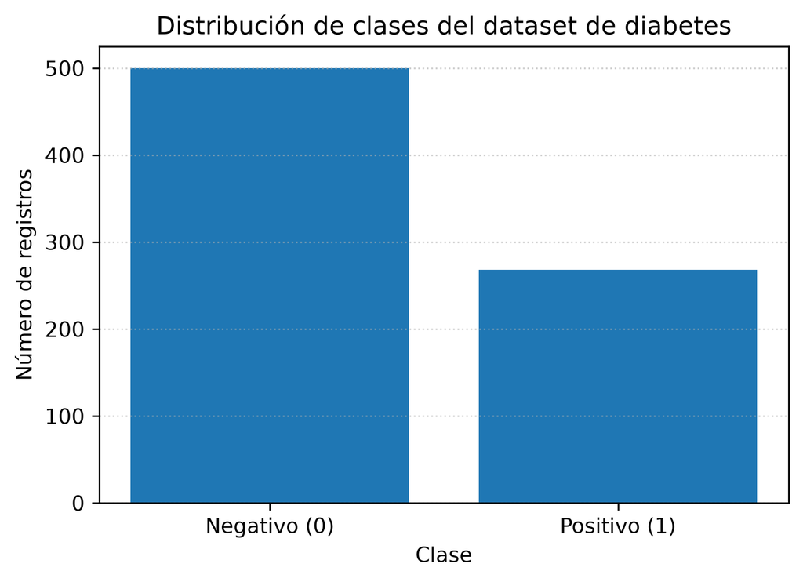

```
Gráfica guardada en: outputs\graficas\distribucion_clases_dataset.png
```

```python
# Gráfica de distribución de clases.

class_counts = df["Outcome"].value_counts().sort_index()
class_labels = ["Negativo (0)", "Positivo (1)"]

plt.figure(figsize=(6, 4))
plt.bar(class_labels, class_counts.values)
plt.title("Distribución de clases del dataset de diabetes")
plt.xlabel("Clase")
plt.ylabel("Número de registros")
plt.grid(axis="y", linestyle=":", alpha=0.6)

output_path = OUTPUT_GRAPHS / "distribucion_clases_dataset.png"
plt.savefig(output_path, dpi=300, bbox_inches="tight")
plt.close()
display_responsive_image(output_path, max_width_px=650)

print(f"Gráfica guardada en: {format_relative_path(output_path)}")
```

## 7. Preparación de los datos

La variable objetivo `Outcome` ya se encuentra codificada numéricamente. La clase `1` se considera positiva porque representa presencia del resultado clínico de diabetes.

A diferencia de una partición entrenamiento/prueba tradicional, aquí se utiliza **K-Folds estratificado con 10 particiones**. En cada iteración, aproximadamente el 90% de los registros se usa para entrenamiento y el 10% restante se reserva para prueba. Para evitar fuga de datos, el escalamiento de SVM y MLP se integra dentro de `Pipeline`, de modo que el `StandardScaler` se ajusta únicamente con los datos de entrenamiento de cada fold.

```python
# Preparación de variables predictoras y variable objetivo.

X = df[FEATURE_COLUMNS].copy()
y = df["Outcome"].copy()

print("Variables predictoras:")
print(FEATURE_COLUMNS)

print("\nVariable objetivo: Outcome")
print("Clase negativa: 0")
print("Clase positiva: 1")

print(f"\nMatriz X: {X.shape}")
print(f"Vector y: {y.shape}")
```

```
Variables predictoras:
['Pregnancies', 'Glucose', 'BloodPressure', 'SkinThickness', 'Insulin', 'BMI', 'DiabetesPedigreeFunction', 'Age']

Variable objetivo: Outcome
Clase negativa: 0
Clase positiva: 1

Matriz X: (768, 8)
Vector y: (768,)
```

## 8. Implementación de las máquinas de aprendizaje supervisado con K-Folds

Se implementan tres modelos predictivos:

1. **Random Forest**: ensamble de árboles con votación mayoritaria.
2. **SVM Lineal**: clasificador de margen máximo con estandarización.
3. **Red Neuronal MLP**: modelo no lineal con una capa oculta compacta y estandarización.

Todos los modelos se evalúan con el mismo objeto `StratifiedKFold`, garantizando que la comparación sea homogénea y que la proporción de clases se mantenga aproximadamente en cada fold.

```python
# Funciones de construcción de modelos y evaluación K-Folds.

def build_model_pipelines(random_state: int = RANDOM_STATE) -> dict[str, object]:
    """Construye los modelos supervisados utilizados en la práctica.

    La función separa la configuración de algoritmos del proceso de evaluación.
    SVM y MLP se implementan como pipelines con StandardScaler para evitar
    fuga de datos durante K-Folds. Random Forest se usa sin escalamiento porque
    los árboles de decisión no dependen de la escala de las variables.

    Args:
        random_state: Semilla para reproducibilidad experimental.

    Returns:
        Diccionario donde cada clave es el nombre del modelo y cada valor es
        un estimador compatible con scikit-learn.

    Raises:
        ValueError: Si random_state no es entero no negativo.
    """
    if not isinstance(random_state, int) or random_state < 0:
        raise ValueError("random_state debe ser un entero no negativo.")

    models = {
        "Random Forest": RandomForestClassifier(
            n_estimators=15,
            max_depth=5,
            random_state=random_state,
            n_jobs=1,
            class_weight="balanced",
        ),
        "SVM Lineal": Pipeline(
            steps=[
                ("scaler", StandardScaler()),
                ("model", LinearSVC(
                    C=1.0,
                    random_state=random_state,
                    max_iter=2000,
                    dual=False,
                )),
            ]
        ),
        "Red Neuronal MLP": Pipeline(
            steps=[
                ("scaler", StandardScaler()),
                ("model", MLPClassifier(
                    hidden_layer_sizes=(8,),
                    activation="relu",
                    solver="adam",
                    alpha=0.001,
                    max_iter=40,
                    random_state=random_state,
                    early_stopping=False,
                )),
            ]
        ),
    }

    LOGGER.info("Modelos construidos: %s", list(models.keys()))
    return models


def run_kfolds_predictions(
    models: dict[str, object],
    X_input: pd.DataFrame,
    y_input: pd.Series,
    n_splits: int = N_SPLITS,
    random_state: int = RANDOM_STATE,
) -> dict[str, np.ndarray]:
    """Ejecuta K-Folds estratificado para cada modelo y obtiene predicciones fuera de muestra.

    Para cada algoritmo, la función divide el dataset en k folds. En cada
    iteración, un fold queda como prueba y los folds restantes se usan para
    entrenamiento. El resultado es un vector de predicciones comparable con y_input.

    Args:
        models: Diccionario de estimadores supervisados.
        X_input: Matriz de variables predictoras.
        y_input: Vector de clases reales.
        n_splits: Número de folds usados en la validación cruzada.
        random_state: Semilla para reproducibilidad.

    Returns:
        Diccionario con las predicciones K-Folds de cada modelo.

    Raises:
        TypeError: Si models no es un diccionario.
        ValueError: Si X_input y y_input tienen tamaños incompatibles o n_splits es inválido.
        RuntimeError: Si ocurre un error durante la validación cruzada.
    """
    if not isinstance(models, dict) or not models:
        raise TypeError("models debe ser un diccionario no vacío.")

    if len(X_input) != len(y_input):
        raise ValueError("X_input y y_input deben tener el mismo número de registros.")

    if not isinstance(n_splits, int) or n_splits < 2:
        raise ValueError("n_splits debe ser un entero mayor o igual a 2.")

    kfolds = StratifiedKFold(
        n_splits=n_splits,
        shuffle=True,
        random_state=random_state,
    )
    predictions = {}

    for model_name, estimator in models.items():
        try:
            LOGGER.info("Iniciando K-Folds para: %s", model_name)
            y_pred = cross_val_predict(
                estimator=estimator,
                X=X_input,
                y=y_input,
                cv=kfolds,
                n_jobs=1,
                method="predict",
            )
            predictions[model_name] = y_pred
            LOGGER.info("K-Folds finalizado para: %s", model_name)
        except Exception as exc:
            LOGGER.exception("Error durante K-Folds en el modelo %s", model_name)
            raise RuntimeError(f"No fue posible ejecutar K-Folds para {model_name}.") from exc

    return predictions
```

### Aclaración sobre el entrenamiento en K-Folds

En K-Folds cada modelo se entrena tantas veces como folds se definan. En esta práctica se utiliza `k = 10`, por lo que cada algoritmo se entrena 10 veces: en cada iteración utiliza aproximadamente el 90% de los registros para entrenamiento y el 10% para prueba.

Por esta razón, aunque no se realiza una única partición fija entrenamiento/prueba, sí existe entrenamiento supervisado en cada iteración del procedimiento K-Folds.

```python
# Ejecución de K-Folds.

models = build_model_pipelines(random_state=RANDOM_STATE)
cache_path = OUTPUT_TABLES / "predicciones_kfolds_cache.csv"

if cache_path.exists():
    LOGGER.info("Se encontró caché de predicciones K-Folds: %s", format_relative_path(cache_path))
    prediction_cache_df = pd.read_csv(cache_path)
    kfolds_predictions = {
        "Random Forest": prediction_cache_df["Random Forest"].to_numpy(),
        "SVM Lineal": prediction_cache_df["SVM Lineal"].to_numpy(),
        "Red Neuronal MLP": prediction_cache_df["Red Neuronal MLP"].to_numpy(),
    }
else:
    LOGGER.info("No se encontró caché. Se ejecutará K-Folds completo.")
    kfolds_predictions = run_kfolds_predictions(models, X, y, n_splits=N_SPLITS, random_state=RANDOM_STATE)
    prediction_cache_df = pd.DataFrame({"Outcome_real": y})
    for model_name, y_pred in kfolds_predictions.items():
        prediction_cache_df[model_name] = y_pred
    prediction_cache_df.to_csv(cache_path, index=False)

print("Predicciones K-Folds disponibles correctamente.")
for model_name, y_pred in kfolds_predictions.items():
    print(f"{model_name}: {len(y_pred)} predicciones")

print(f"Caché K-Folds: {format_relative_path(cache_path)}")
```

```
2026-07-05 23:14:31,154 | INFO | Modelos construidos: ['Random Forest', 'SVM Lineal', 'Red Neuronal MLP']
```

```
2026-07-05 23:14:31,154 | INFO | Se encontró caché de predicciones K-Folds: outputs\tablas\predicciones_kfolds_cache.csv
```

```
Predicciones K-Folds disponibles correctamente.
Random Forest: 768 predicciones
SVM Lineal: 768 predicciones
Red Neuronal MLP: 768 predicciones
Caché K-Folds: outputs\tablas\predicciones_kfolds_cache.csv
```

## 9. Prueba de las máquinas de aprendizaje supervisado

La prueba se realiza mediante las predicciones obtenidas con **K-Folds**. Para cada modelo se construye una matriz de confusión y se calculan las métricas solicitadas:

- Precisión Global.
- Error Global.
- Precisión Positiva (PP).
- Precisión Negativa (PN).
- Falsos Positivos (FP).
- Falsos Negativos (FN).
- Asertividad Positiva (AP).
- Asertividad Negativa (NP).

```python
# Funciones de cálculo de métricas solicitadas.

def safe_divide(numerator: float, denominator: float) -> float:
    """Divide dos valores evitando errores por división entre cero.

    Args:
        numerator: Numerador de la operación.
        denominator: Denominador de la operación.

    Returns:
        Resultado de la división. Si el denominador es cero, devuelve 0.0.
    """
    if denominator == 0:
        return 0.0
    return numerator / denominator


def calculate_requested_metrics(
    y_true: pd.Series,
    y_pred: np.ndarray,
    model_name: str,
) -> dict[str, float | int | str]:
    """Calcula métricas de clasificación solicitadas por la práctica.

    La matriz de confusión se interpreta con la clase 0 como negativa y
    la clase 1 como positiva. A partir de TN, FP, FN y TP se calculan
    precisión global, error global, precisión positiva, precisión negativa,
    asertividad positiva y asertividad negativa.

    Args:
        y_true: Etiquetas reales.
        y_pred: Etiquetas predichas mediante K-Folds.
        model_name: Nombre descriptivo del modelo evaluado.

    Returns:
        Diccionario con métricas y conteos principales.

    Raises:
        ValueError: Si los vectores de entrada tienen longitudes distintas.
    """
    if len(y_true) != len(y_pred):
        raise ValueError("y_true y y_pred deben tener la misma longitud.")

    cm = confusion_matrix(y_true, y_pred, labels=[0, 1])
    tn, fp, fn, tp = cm.ravel()
    total = tn + fp + fn + tp

    metrics = {
        "Modelo": model_name,
        "TN": int(tn),
        "FP": int(fp),
        "FN": int(fn),
        "TP": int(tp),
        "Precisión Global": safe_divide(tp + tn, total),
        "Error Global": safe_divide(fp + fn, total),
        "PP": safe_divide(tp, tp + fn),
        "PN": safe_divide(tn, tn + fp),
        "AP": safe_divide(tp, tp + fp),
        "NP": safe_divide(tn, tn + fn),
    }

    return metrics


def build_comparative_metrics_table(
    y_true: pd.Series,
    predictions: dict[str, np.ndarray],
) -> pd.DataFrame:
    """Construye una tabla comparativa con las métricas solicitadas.

    Args:
        y_true: Etiquetas reales del dataset.
        predictions: Diccionario con predicciones K-Folds por modelo.

    Returns:
        DataFrame comparativo ordenado por precisión global descendente.

    Raises:
        TypeError: Si predictions no es un diccionario.
    """
    if not isinstance(predictions, dict) or not predictions:
        raise TypeError("predictions debe ser un diccionario no vacío.")

    rows = [
        calculate_requested_metrics(y_true, y_pred, model_name)
        for model_name, y_pred in predictions.items()
    ]

    metrics_df = pd.DataFrame(rows)
    metrics_df = metrics_df.sort_values("Precisión Global", ascending=False).reset_index(drop=True)
    return metrics_df
```

```python
# Tabla comparativa de métricas solicitadas.

metrics_df = build_comparative_metrics_table(y, kfolds_predictions)

metrics_path = OUTPUT_TABLES / "metricas_kfolds_modelos.csv"
metrics_df.to_csv(metrics_path, index=False)

display_responsive_table(
    metrics_df.round(4),
    title="Tabla comparativa de métricas K-Folds",
    min_width_px=980,
    index=False,
)

print(f"Tabla guardada en: {format_relative_path(metrics_path)}")
```

Tabla comparativa de métricas K-Folds

| Modelo | TN | FP | FN | TP | Precisión Global | Error Global | PP | PN | AP | NP |
| --- | --- | --- | --- | --- | --- | --- | --- | --- | --- | --- |
| Random Forest | 373 | 127 | 61 | 207 | 0.7552 | 0.2448 | 0.7724 | 0.746 | 0.6198 | 0.8594 |
| SVM Lineal | 385 | 115 | 78 | 190 | 0.7487 | 0.2513 | 0.7090 | 0.770 | 0.6230 | 0.8315 |
| Red Neuronal MLP | 372 | 128 | 100 | 168 | 0.7031 | 0.2969 | 0.6269 | 0.744 | 0.5676 | 0.7881 |

```
Tabla guardada en: outputs\tablas\metricas_kfolds_modelos.csv
```

### 9.1 Matriz de confusión - Random Forest

La matriz de confusión del modelo Random Forest permite observar la cantidad de pacientes positivos y negativos clasificados correctamente o incorrectamente bajo K-Folds.

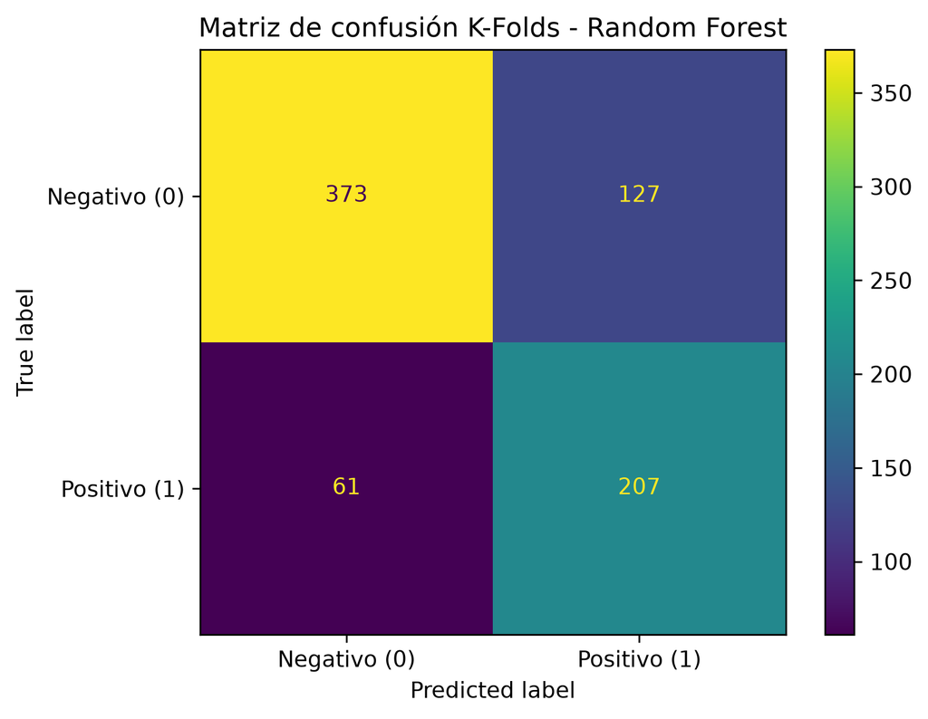

```
Gráfica guardada en: outputs\graficas\matriz_confusion_kfolds_random_forest.png
```

```python
# Matriz de confusión - Random Forest.

cm_rf = confusion_matrix(y, kfolds_predictions["Random Forest"], labels=[0, 1])

disp = ConfusionMatrixDisplay(
    confusion_matrix=cm_rf,
    display_labels=["Negativo (0)", "Positivo (1)"],
)
disp.plot(values_format="d")
plt.title("Matriz de confusión K-Folds - Random Forest")
plt.grid(False)

output_path = OUTPUT_GRAPHS / "matriz_confusion_kfolds_random_forest.png"
plt.savefig(output_path, dpi=300, bbox_inches="tight")
plt.close()
display_responsive_image(output_path, max_width_px=520)

print(f"Gráfica guardada en: {format_relative_path(output_path)}")
```

### 9.2 Matriz de confusión - SVM Lineal

La matriz de confusión del modelo SVM Lineal permite identificar su capacidad de separación entre clases negativas y positivas mediante una frontera geométrica lineal.

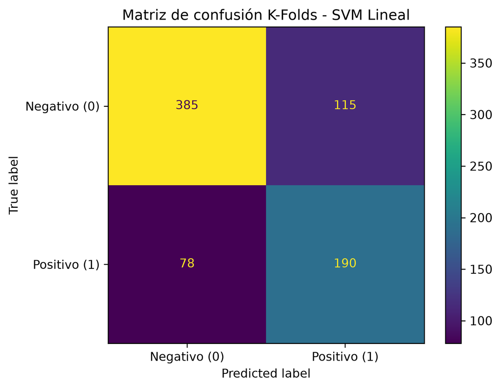

```
Gráfica guardada en: outputs\graficas\matriz_confusion_kfolds_svm_lineal.png
```

```python
# Matriz de confusión - SVM Lineal.

cm_svm = confusion_matrix(y, kfolds_predictions["SVM Lineal"], labels=[0, 1])

disp = ConfusionMatrixDisplay(
    confusion_matrix=cm_svm,
    display_labels=["Negativo (0)", "Positivo (1)"],
)
disp.plot(values_format="d")
plt.title("Matriz de confusión K-Folds - SVM Lineal")
plt.grid(False)

output_path = OUTPUT_GRAPHS / "matriz_confusion_kfolds_svm_lineal.png"
plt.savefig(output_path, dpi=300, bbox_inches="tight")
plt.close()
display_responsive_image(output_path, max_width_px=520)

print(f"Gráfica guardada en: {format_relative_path(output_path)}")
```

### 9.3 Matriz de confusión - Red Neuronal MLP

La matriz de confusión del modelo MLP permite analizar el comportamiento de una red neuronal compacta aplicada a datos tabulares clínicos.

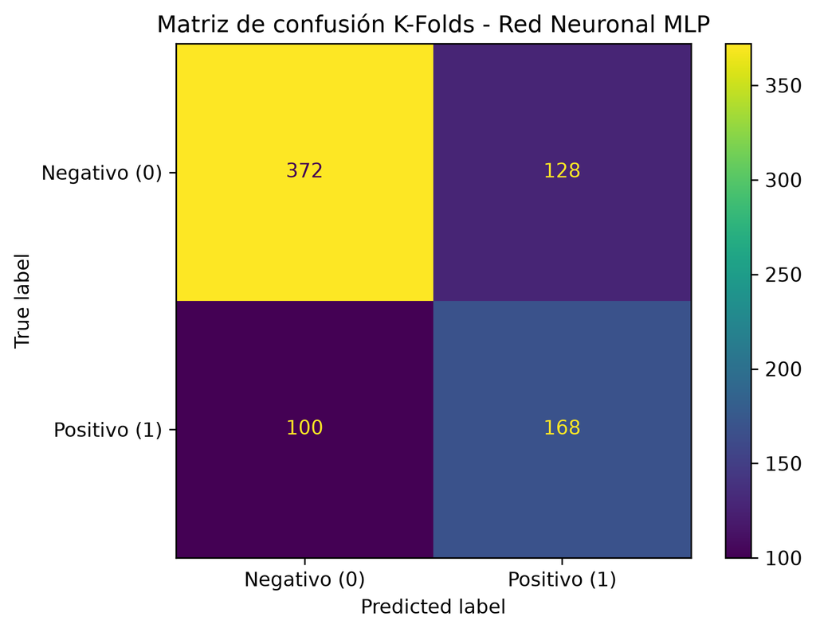

```
Gráfica guardada en: outputs\graficas\matriz_confusion_kfolds_red_neuronal_mlp.png
```

```python
# Matriz de confusión - Red Neuronal MLP.

cm_mlp = confusion_matrix(y, kfolds_predictions["Red Neuronal MLP"], labels=[0, 1])

disp = ConfusionMatrixDisplay(
    confusion_matrix=cm_mlp,
    display_labels=["Negativo (0)", "Positivo (1)"],
)
disp.plot(values_format="d")
plt.title("Matriz de confusión K-Folds - Red Neuronal MLP")
plt.grid(False)

output_path = OUTPUT_GRAPHS / "matriz_confusion_kfolds_red_neuronal_mlp.png"
plt.savefig(output_path, dpi=300, bbox_inches="tight")
plt.close()
display_responsive_image(output_path, max_width_px=520)

print(f"Gráfica guardada en: {format_relative_path(output_path)}")
```

### 9.4 Comparación gráfica de métricas

La siguiente gráfica resume las métricas proporcionales solicitadas para los tres modelos. Los conteos de FP y FN se mantienen en la tabla porque representan errores absolutos y no proporciones.

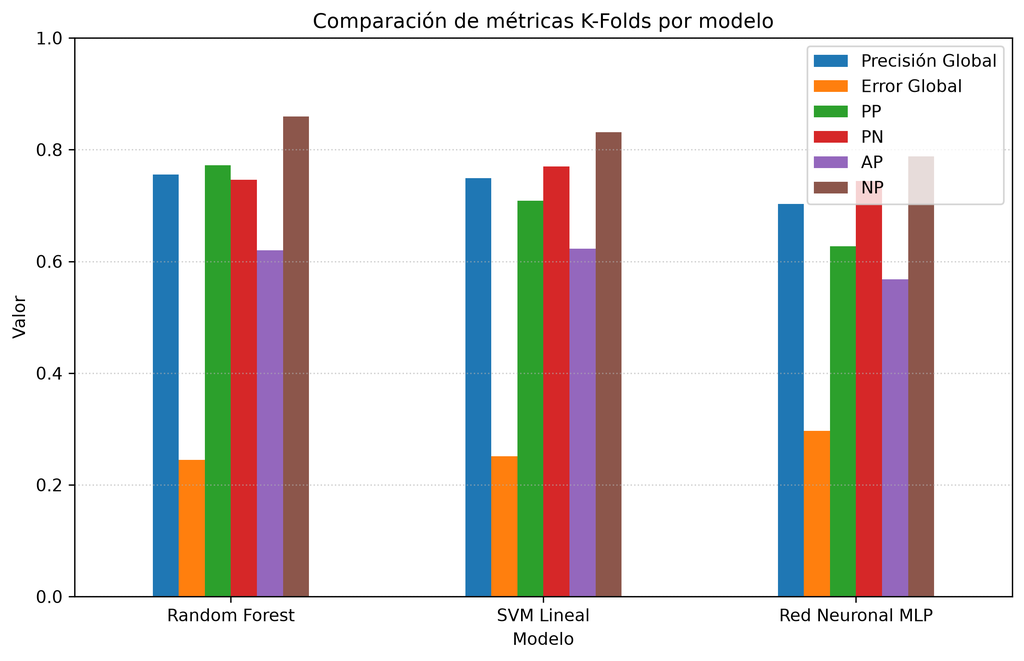

```
Gráfica guardada en: outputs\graficas\comparacion_metricas_kfolds.png
```

```python
# Gráfica comparativa de métricas proporcionales.

metric_columns = ["Precisión Global", "Error Global", "PP", "PN", "AP", "NP"]
plot_df = metrics_df[["Modelo"] + metric_columns].set_index("Modelo")

ax = plot_df.plot(kind="bar", figsize=(10, 6))
plt.title("Comparación de métricas K-Folds por modelo")
plt.xlabel("Modelo")
plt.ylabel("Valor")
plt.ylim(0, 1)
plt.xticks(rotation=0)
plt.grid(axis="y", linestyle=":", alpha=0.6)
plt.legend(loc="best")

output_path = OUTPUT_GRAPHS / "comparacion_metricas_kfolds.png"
plt.savefig(output_path, dpi=300, bbox_inches="tight")
plt.close()
display_responsive_image(output_path, max_width_px=650)

print(f"Gráfica guardada en: {format_relative_path(output_path)}")
```

### 9.5 Importancia de variables - Random Forest

Aunque la comparación principal se realiza mediante métricas K-Folds, Random Forest permite estimar la importancia relativa de las variables predictoras. Para esta visualización se ajusta un modelo final con todo el dataset únicamente con fines interpretativos; la evaluación comparativa sigue siendo la obtenida mediante K-Folds.

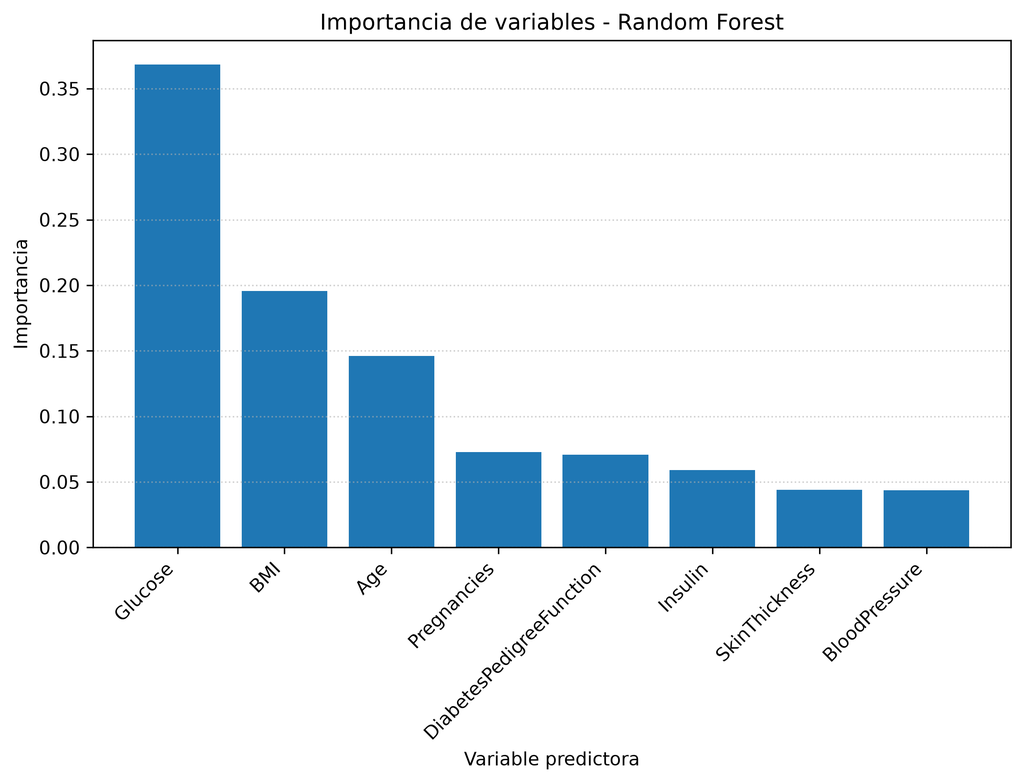

Importancia de variables - Random Forest

| variable | importancia |
| --- | --- |
| Glucose | 0.3682 |
| BMI | 0.1957 |
| Age | 0.1460 |
| Pregnancies | 0.0727 |
| DiabetesPedigreeFunction | 0.0707 |
| Insulin | 0.0589 |
| SkinThickness | 0.0440 |
| BloodPressure | 0.0437 |

```
Tabla guardada en: outputs\tablas\importancia_variables_random_forest.csv
Gráfica guardada en: outputs\graficas\importancia_variables_kfolds_random_forest.png
```

```python
# Importancia de variables - Random Forest.

rf_final = RandomForestClassifier(
    n_estimators=100,
    max_depth=5,
    random_state=RANDOM_STATE,
    n_jobs=1,
    class_weight="balanced",
)
rf_final.fit(X, y)

importance_df = pd.DataFrame({
    "variable": FEATURE_COLUMNS,
    "importancia": rf_final.feature_importances_,
}).sort_values("importancia", ascending=False)

importance_path = OUTPUT_TABLES / "importancia_variables_random_forest.csv"
importance_df.to_csv(importance_path, index=False)

plt.figure(figsize=(9, 5))
plt.bar(importance_df["variable"], importance_df["importancia"])
plt.title("Importancia de variables - Random Forest")
plt.xlabel("Variable predictora")
plt.ylabel("Importancia")
plt.xticks(rotation=45, ha="right")
plt.grid(axis="y", linestyle=":", alpha=0.6)

output_path = OUTPUT_GRAPHS / "importancia_variables_kfolds_random_forest.png"
plt.savefig(output_path, dpi=300, bbox_inches="tight")
plt.close()
display_responsive_image(output_path, max_width_px=650)

display_responsive_table(
    importance_df.round(4),
    title="Importancia de variables - Random Forest",
    min_width_px=620,
    index=False,
)

print(f"Tabla guardada en: {format_relative_path(importance_path)}")
print(f"Gráfica guardada en: {format_relative_path(output_path)}")
```

## 10. Interpretación de resultados

La comparación mediante **K-Folds** muestra que los modelos presentan comportamientos distintos ante el mismo problema de clasificación. Aunque las diferencias entre Random Forest y SVM Lineal son pequeñas, el análisis de las métricas permite identificar fortalezas específicas.

**Random Forest** obtiene la mayor **Precisión Global (0.7552)** y la mayor **Precisión Positiva (PP = 0.7724)**. Además, presenta el menor número de **Falsos Negativos (FN = 61)**, aspecto relevante en un problema médico porque reduce el riesgo de clasificar como sano a un paciente con diabetes.

**SVM Lineal** obtiene un desempeño global cercano (**0.7487**) y presenta menos falsos positivos que Random Forest. Sin embargo, genera más falsos negativos (**FN = 78**), por lo que detecta menos casos positivos reales.

**Red Neuronal MLP** obtiene el menor desempeño global (**0.7031**) bajo esta configuración. Aunque puede modelar relaciones no lineales, no supera a Random Forest ni a SVM Lineal en las métricas principales.

En términos prácticos, **Random Forest** resulta la alternativa más conveniente bajo esta configuración K-Folds, ya que combina la mejor precisión global, la mayor detección de casos positivos y el menor número de falsos negativos.

```python
# Comentario automático breve según precisión global y precisión positiva.

best_global = metrics_df.sort_values("Precisión Global", ascending=False).iloc[0]
best_positive = metrics_df.sort_values("PP", ascending=False).iloc[0]

print("Resumen comparativo:")
print(metrics_df.round(4).to_string(index=False))

print(f"\nMejor precisión global: {best_global['Modelo']} ({best_global['Precisión Global']:.4f})")
print(f"Mejor precisión positiva PP: {best_positive['Modelo']} ({best_positive['PP']:.4f})")
```

```
Resumen comparativo:
          Modelo  TN  FP  FN  TP  Precisión Global  Error Global     PP    PN     AP     NP
   Random Forest 373 127  61 207            0.7552        0.2448 0.7724 0.746 0.6198 0.8594
      SVM Lineal 385 115  78 190            0.7487        0.2513 0.7090 0.770 0.6230 0.8315
Red Neuronal MLP 372 128 100 168            0.7031        0.2969 0.6269 0.744 0.5676 0.7881

Mejor precisión global: Random Forest (0.7552)
Mejor precisión positiva PP: Random Forest (0.7724)
```

## 11. Conclusiones

1. La práctica permitió implementar, evaluar y comparar máquinas de aprendizaje supervisado mediante **K-Folds**, utilizando el dataset de diabetes como problema de clasificación binaria.
2. K-Folds permitió evaluar los modelos mediante 10 particiones estratificadas. En cada iteración, un fold se reservó para prueba y los folds restantes se usaron para entrenamiento, manteniendo aproximadamente la proporción de clases.
3. **Random Forest** obtuvo la mejor precisión global (**0.7552**) y el menor error global (**0.2448**), por lo que fue el modelo con mejor desempeño general bajo esta configuración experimental.
4. **Random Forest** también obtuvo la mejor precisión positiva (**PP = 0.7724**) y el menor número de falsos negativos (**FN = 61**), aspecto relevante en un problema médico porque reduce el riesgo de no detectar pacientes con diabetes.
5. **SVM Lineal** presentó un desempeño cercano al de Random Forest, con una precisión global de **0.7487**, pero generó más falsos negativos (**FN = 78**).
6. **Red Neuronal MLP** obtuvo el menor desempeño global entre los tres modelos. Aunque puede modelar relaciones no lineales, en esta configuración compacta no superó a Random Forest ni a SVM Lineal.
7. Desde el punto de vista metodológico, el uso de pipelines con escalamiento interno evitó fuga de datos durante K-Folds, fortaleciendo la validez experimental de la práctica.
8. En conjunto, la práctica permitió comprender la importancia de evaluar modelos supervisados con métricas clínicas relevantes, ya que en el diagnóstico de enfermedades no solo importa acertar más, sino reducir errores críticos como los falsos negativos.

## 12. Referencias

Géron, A. (2019). Hands-on machine learning with Scikit-Learn, Keras, and TensorFlow (2nd ed.). O’Reilly Media.

Gironés Roig, J., Casas Roma, J., Minguillón Alfonso, J., & Caihuelas Quiles, R. (2017). Minería de datos: modelos y algoritmos. Editorial UOC.

Hastie, T., Tibshirani, R., & Friedman, J. (2017). The elements of statistical learning: Data mining, inference, and prediction (2nd ed.). Springer.

Raschka, S., & Mirjalili, V. (2019). Python machine learning (3rd ed.). Packt Publishing.

James, G., Witten, D., Hastie, T., & Tibshirani, R. (2013). An introduction to statistical learning: with applications in R. Springer New York.

Breiman, L. (2001). Random forests. Machine Learning, 45(1), 5-32. https://doi.org/10.1023/A:1010933404324

UCI Machine Learning. (2016). Pima Indians diabetes database [Conjunto de datos]. Kaggle. https://www.kaggle.com/datasets/uciml/pima-indians-diabetes-database